# Michigan 2016 by Kathleen Cravotta

## Contributions Data Set

This exploratory data analysis covers 2016 presidential campaign contributions from residents of Michigan. The data is publicly available on the federal election commission website.<sup>1</sup> Some observations of the data are made in an attempt to discover patterns about candidate support from contributors.

There are approximately 140,000 records comprised of 20 variables containing contribution and contributor information.

```
## [1] 140668
```

```
##       cmte_id           cand_id                           cand_nm
##  C00575795:53912   P00003392:53912   Clinton, Hillary Rodham  :53912
##  C00577130:47890   P60007168:47890   Sanders, Bernard         :47890
##  C00580100:12808   P80001571:12808   Trump, Donald J.         :12808
##  C00574624:11306   P60006111:11306   Cruz, Rafael Edward 'Ted':11306
##  C00573519: 9075   P60005915: 9075   Carson, Benjamin S.      : 9075
##  C00458844: 1726   P60006723: 1726   Rubio, Marco             : 1726
##  (Other)  : 3951   (Other)  : 3951   (Other)                  : 3951
##             contbr_nm            contbr_city     contbr_st
##  NAGEL, PATRICIA :   324   ANN ARBOR   : 11631   MI:140668
##  WEINER, JUDITH  :   212   GRAND RAPIDS:  5895
##  SIMONS, BONNIE S:   179   DETROIT     :  3668
##  ZENZEN, EUGENE  :   155   KALAMAZOO   :  2994
##  TORRES, RICHARD :   151   LANSING     :  2723
##  SPECIAL, MICKI  :   145   ROYAL OAK   :  2538
##  (Other)         :139502   (Other)     :111219
##    contbr_zip             contbr_employer              contbr_occupation
##  Min.   :        0   RETIRED      :21475   RETIRED              :36432
##  1st Qu.:481041003   N/A          :18983   NOT EMPLOYED         :15063
##  Median :483124265   NONE         :11776   INFORMATION REQUESTED: 4486
##  Mean   :431511706   SELF-EMPLOYED: 6467   PROFESSOR            : 2904
##  3rd Qu.:490099393   NOT EMPLOYED : 6161   ATTORNEY             : 2495
##  Max.   :499699747   (Other)      :75692   (Other)              :79268
##  NA's   :8           NA's         :  114   NA's                 :   20
##  contb_receipt_amt  contb_receipt_dt
##  Min.   :-5400.0   12-JUL-16:  1712
##  1st Qu.:   15.0   11-JUL-16:  1667
##  Median :   27.0   29-FEB-16:  1656
##  Mean   :  101.4   31-MAR-16:  1486
##  3rd Qu.:   76.0   09-MAR-16:  1369
##  Max.   :10800.0   31-MAY-16:  1288
##                    (Other)  :131490
##                            receipt_desc    memo_cd
##                                  :139028    :118502
##  Refund                          :   801   X: 22166
##  REDESIGNATION FROM PRIMARY      :   189
##  REDESIGNATION TO GENERAL        :   188
##  REDESIGNATION TO CRUZ FOR SENATE:    94
##  SEE REDESIGNATION               :    72
##  (Other)                         :   296
```

[output cut: 9 more lines]

```
##  Min.   :1003942   SA17.1196417:     3        :   306
##  1st Qu.:1077572   C1015053    :     2   G2016: 33547
##  Median :1091718   C1015276    :     2   P2015:     1
##  Mean   :1087973   C1015569    :     2   P2016:106813
##  3rd Qu.:1104813   C10180094   :     2   P2020:     1
##  Max.   :1119833   C10194369   :     2
##                    (Other)     :140655
##       date
##  Min.   :2013-10-07
##  1st Qu.:2016-02-20
##  Median :2016-04-25
##  Mean   :2016-04-23
##  3rd Qu.:2016-07-21
##  Max.   :2016-10-19
##
```

# Univariate Plots Section

### Number of contributions per candidate

Of most interest in the data set is the presidential candidates for which the contribution was made. This graph illustrates that Clinton and Sanders had the highest numbers of contributions.

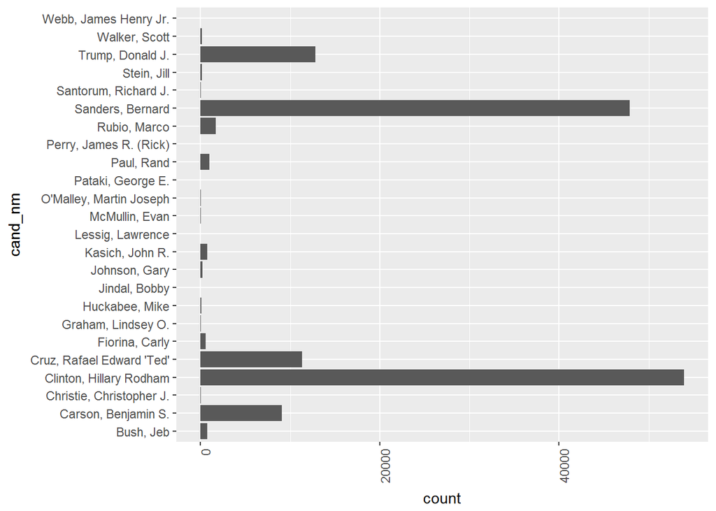

### Enriching the Data Set

The gender<sup>2</sup> and political party<sup>3</sup> for each candidate was used to enrich the data set. This publicly available information provides interesting dimensions. The political party of the candidates is helpful for guaging the voter support tendencies.

```
##                     cand_nm gender  pol_party
## 1 Cruz, Rafael Edward 'Ted'   male Republican
## 2   Clinton, Hillary Rodham female   Democrat
## 3          Sanders, Bernard   male   Democrat
## 4             Walker, Scott   male Republican
## 5                 Bush, Jeb   male Republican
## 6              Rubio, Marco   male Republican
```

Here is the distribution of donations per political party

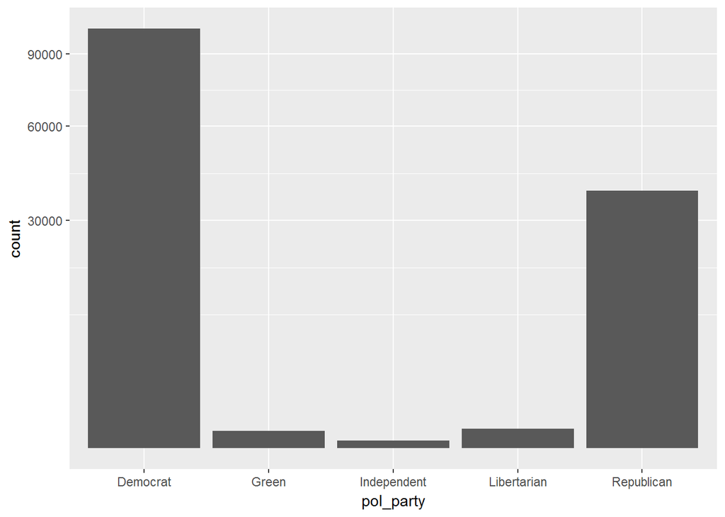

Checking dates

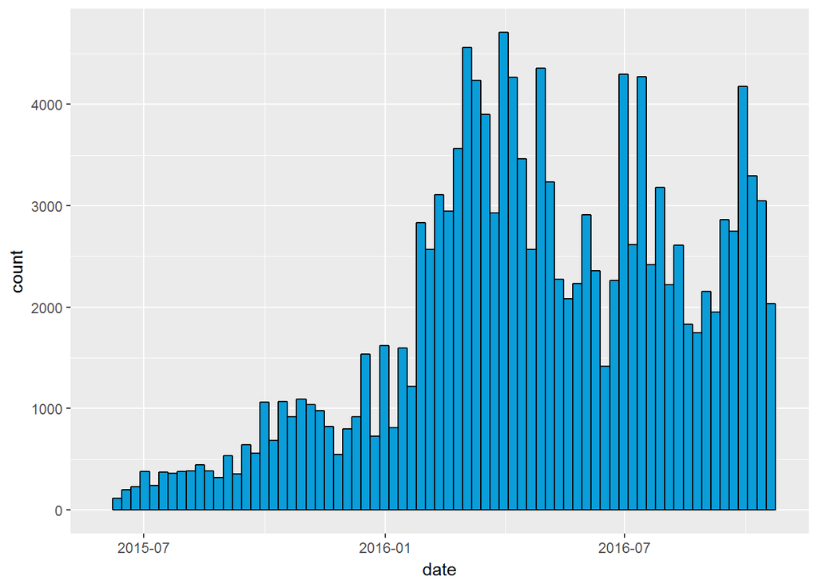

### Size of contribution vs. Number of contributions

This section aims to provide a visualization of the number of contributions. The majority of contributions are clustered at the low end of the default graph, at 100 or less.

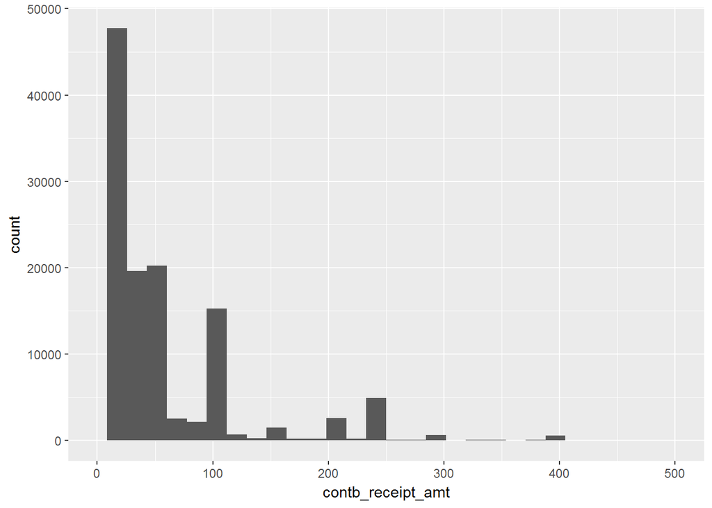

By scaling the y-axis and setting the binwidth, there’s better visibility to the details.

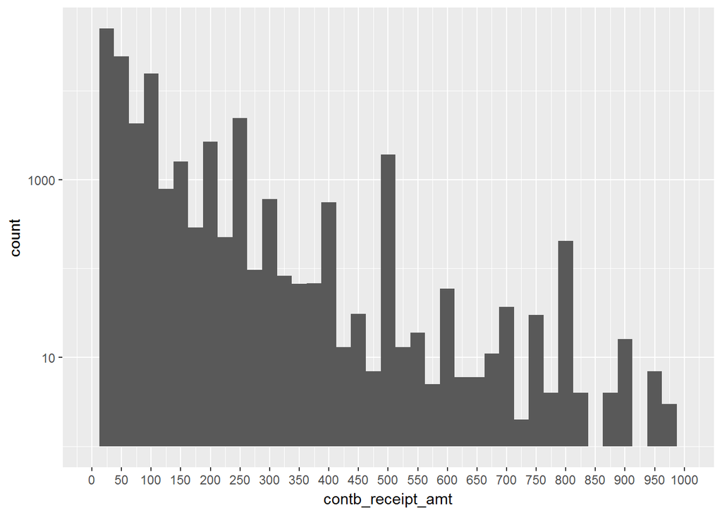

The above graph was further enhanced by using transformations on the x-axis. The bottom graph here is an ideally distributed graph that provides a good level of detail for each magnitude of the data.

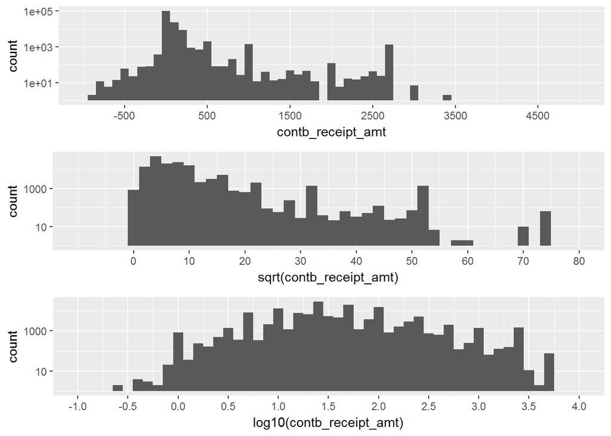

After finding a good distribution of the data, the same plot was then split in to 5 separate plots, one for each political party.

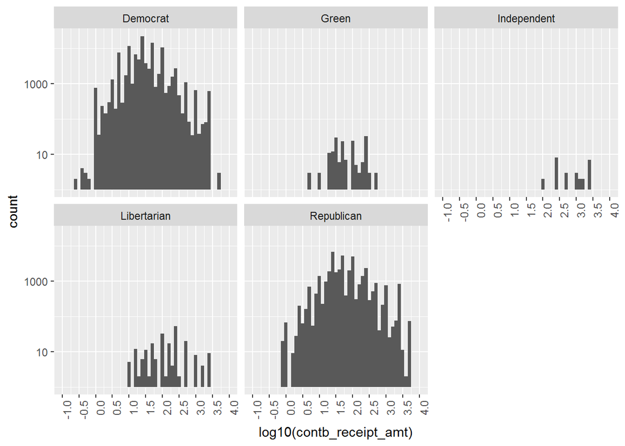

# Univariate Analysis

### What is the structure of your dataset?

The data is a list of each contribution (or refund or reallocation) of money to a presidential candidate’s campaign. Each contribution has transactional information like the date, amount, and form type, as well as information about the contributor including their name, city, and occupation.

### What is/are the main feature(s) of interest in your dataset?

The number of contributions, amount and candidate are of most interest. The number of contributions give a general idea of how much support the campaign has. An added feature, the political party of the candidate, helps to visualize the support between different parties.

### What other features in the dataset do you think will help support your investigation into your feature(s) of interest?

The date of the contribution is interesting to see how campaign support evolves and reacts. The city is interesting for isolating which regions have strong support for which candidates.

### Of the features you investigated, were there any unusual distributions? Did you perform any operations on the data to tidy, adjust, or change the form of the data? If so, why did you do this?

The contribution receipt date was parsed to a date data type for easier sorting.

# Bivariate Plots Section

### Pairing variables in plots

Here are pairwise plots for some of the key contribution information

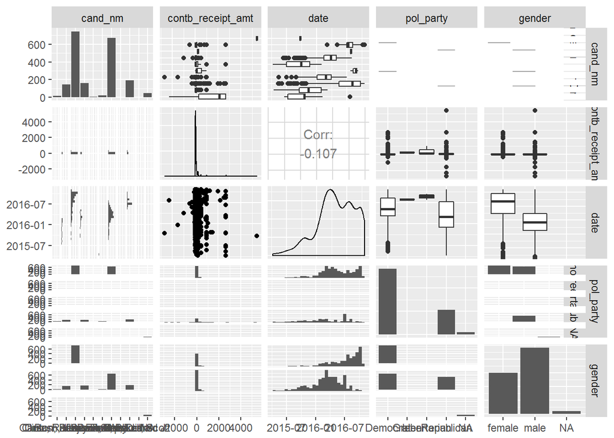

### Contribution Totals per Political Party

The total amount of the contributions per political party indicates that Democrats raised the highest amounts, followed by Republicans, and the other parties had little financial support from followers.

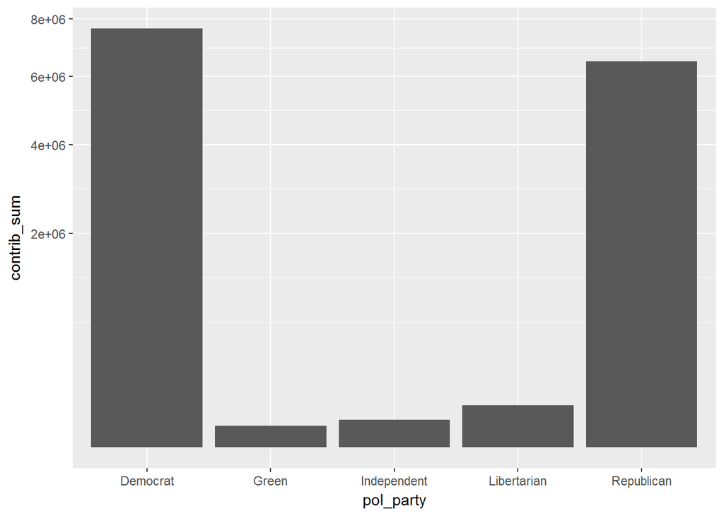

### Contribution Totals per Candidate

The total amount of the contributions per candidate shows that Clinton raised the most amount of money, while Donald Trump and Bernie Sanders raised similar amounts. Although Clinton and Bernie had a closer number of donations, it appears Bernie’s average was likely much lower than Clinton’s and Trump’s.

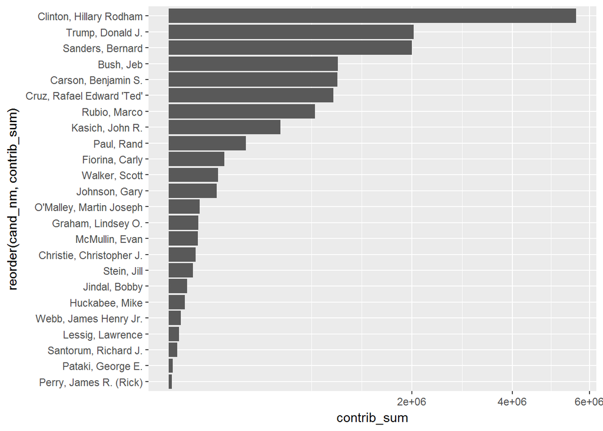

### Statistics for each candidate

Simply display how many contributions and how much they were, for each candidate.

```
##
##                 Bush, Jeb       Carson, Benjamin S.
##                       768                      9075
##  Christie, Christopher J.   Clinton, Hillary Rodham
##                        18                     53912
## Cruz, Rafael Edward 'Ted'            Fiorina, Carly
##                     11306                       551
##        Graham, Lindsey O.            Huckabee, Mike
##                        40                       117
##             Jindal, Bobby             Johnson, Gary
##                         6                       217
##           Kasich, John R.          Lessig, Lawrence
##                       779                        12
##            McMullin, Evan   O'Malley, Martin Joseph
##                        24                        51
##         Pataki, George E.                Paul, Rand
##                         2                      1012
##    Perry, James R. (Rick)              Rubio, Marco
##                         2                      1726
##          Sanders, Bernard      Santorum, Richard J.
##                     47890                        28
##               Stein, Jill          Trump, Donald J.
##                       177                     12808
##             Walker, Scott     Webb, James Henry Jr.
##                       139                         8
```

```
## contributions$cand_nm: Bush, Jeb
##     Min.  1st Qu.   Median     Mean  3rd Qu.     Max.
## -2700.00    91.88  1000.00  1259.00  2700.00  5400.00
## --------------------------------------------------------
## contributions$cand_nm: Carson, Benjamin S.
##    Min. 1st Qu.  Median    Mean 3rd Qu.    Max.
## -2700.0    25.0    50.0   106.1   100.0  5400.0
## --------------------------------------------------------
## contributions$cand_nm: Christie, Christopher J.
##    Min. 1st Qu.  Median    Mean 3rd Qu.    Max.
##  -800.0   312.5   750.0  1351.0  2700.0  3500.0
## --------------------------------------------------------
## contributions$cand_nm: Clinton, Hillary Rodham
##    Min. 1st Qu.  Median    Mean 3rd Qu.    Max.
## -5400.0    11.0    25.0   104.1    75.0  5400.0
## --------------------------------------------------------
## contributions$cand_nm: Cruz, Rafael Edward 'Ted'
##    Min. 1st Qu.  Median    Mean 3rd Qu.    Max.
## -5400.0    25.0    50.0    81.3   100.0 10800.0
## --------------------------------------------------------
## contributions$cand_nm: Fiorina, Carly
##    Min. 1st Qu.  Median    Mean 3rd Qu.    Max.
##    -5.0    50.0   100.0   188.8   100.0  2700.0
## --------------------------------------------------------
## contributions$cand_nm: Graham, Lindsey O.
##    Min. 1st Qu.  Median    Mean 3rd Qu.    Max.
## -2700.0    25.0    50.0   740.9  2700.0  5400.0
## --------------------------------------------------------
## contributions$cand_nm: Huckabee, Mike
##    Min. 1st Qu.  Median    Mean 3rd Qu.    Max.
##    1.00   25.00   30.00   73.29   99.00 1000.00
## --------------------------------------------------------
## contributions$cand_nm: Jindal, Bobby
##    Min. 1st Qu.  Median    Mean 3rd Qu.    Max.
##   250.0   862.5  2700.0  1883.0  2700.0  2700.0
## --------------------------------------------------------
## contributions$cand_nm: Johnson, Gary
##    Min. 1st Qu.  Median    Mean 3rd Qu.    Max.
##  -67.05   50.00  150.00  357.30  250.00 5000.00
## --------------------------------------------------------
```

[output cut: 40 more lines]

```
## contributions$cand_nm: Stein, Jill
##    Min. 1st Qu.  Median    Mean 3rd Qu.    Max.
##     4.2    29.0    50.0   112.7   200.0  1000.0
## --------------------------------------------------------
## contributions$cand_nm: Trump, Donald J.
##    Min. 1st Qu.  Median    Mean 3rd Qu.    Max.
## -2700.0    28.0    48.0   158.7   184.0  5000.0
## --------------------------------------------------------
## contributions$cand_nm: Walker, Scott
##    Min. 1st Qu.  Median    Mean 3rd Qu.    Max.
## -2700.0   100.0   250.0   594.5   500.0  5400.0
## --------------------------------------------------------
## contributions$cand_nm: Webb, James Henry Jr.
##    Min. 1st Qu.  Median    Mean 3rd Qu.    Max.
##   100.0   237.5   375.0   600.0   625.0  2000.0
```

### Checking date and contribution amounts

An observation from the above plot is that people in the race for a short time have a higher contribution average. Maybe early contributions are higher than later ones.

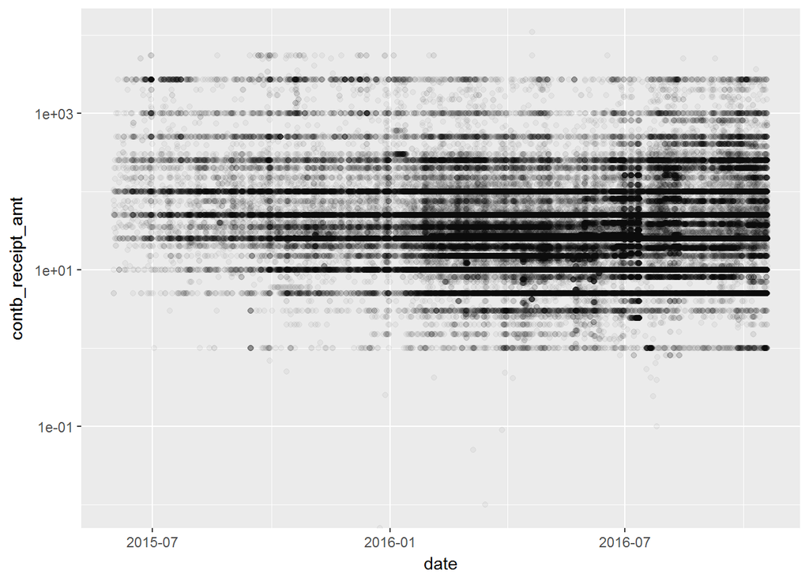

This graph is rather dense, and we can see that there are more contributions on later dates, but we cannot tell if the donation amounts are proportionately less.

Here is a graph of the average contribution per day, followed by the number of contributions per day. We can see here that early in the campaign period, the average contributions tended to be higher, while the number of donations was low.

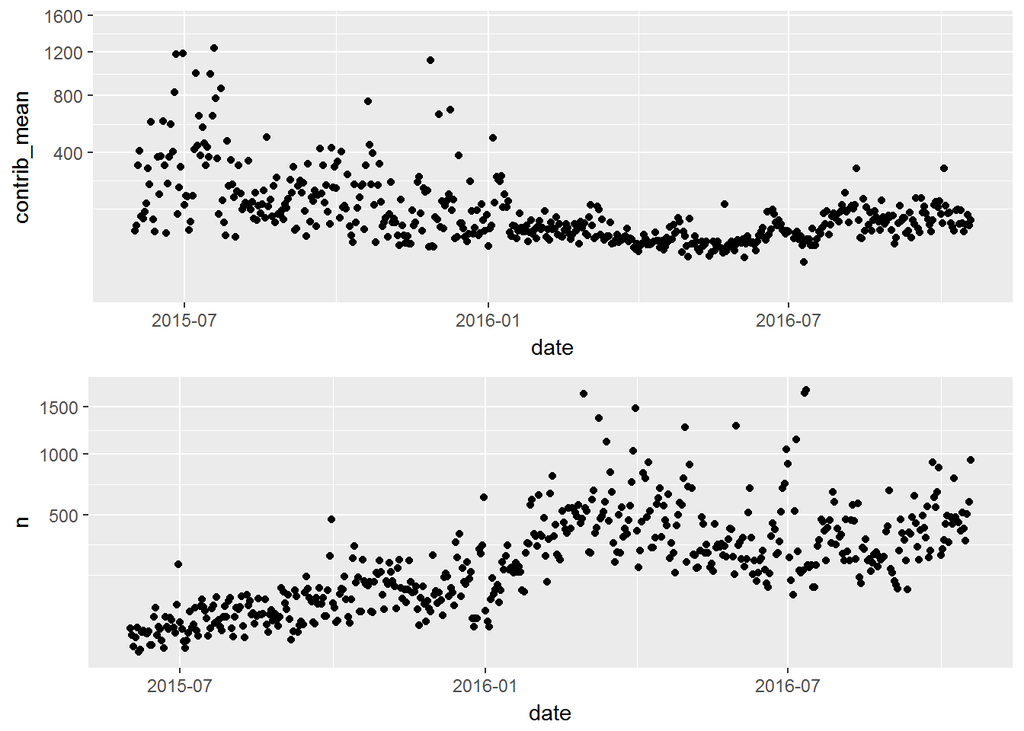

The correlation test of the date and the amount of the contribution indicate that there is correlation.

```
##
##  Pearson's product-moment correlation
##
## data:  as.numeric(contributions$date) and contributions$contb_receipt_amt
## t = -39.833, df = 140670, p-value < 2.2e-16
## alternative hypothesis: true correlation is not equal to 0
## 95 percent confidence interval:
##  -0.1107755 -0.1004405
## sample estimates:
##        cor
## -0.1056108
```

We can also see the relationship of contribution amount and date by looking at the average contribution over time.

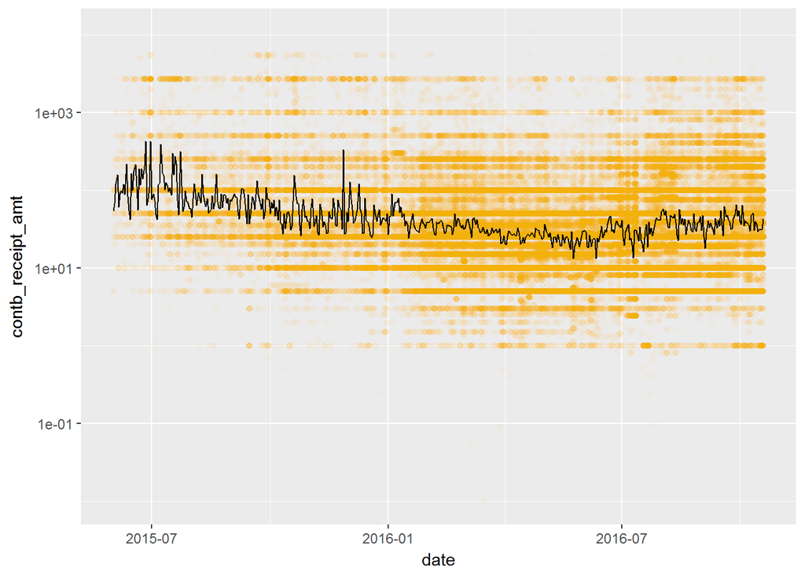

Furthermore, we can see the quantiles of the contributions. Between the two dotted lines is 80% of the contributions.

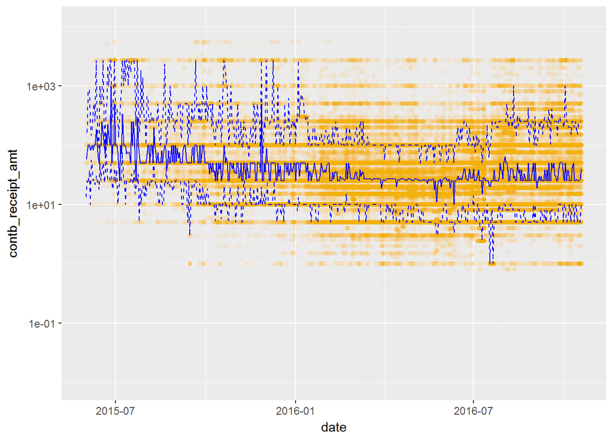

Another visualization of this data uses buckets of donation amounts to count how many donations there were in each range over time during the campaign. With this chart, we can see that early in the campaign, the large and small contribution counts were actually pretty close to each other. But then the number of the smaller donations rose over time.

```
##          (0,25]        (25,100]     (100,1e+03] (1e+03,2.7e+03]
##           61923           59418           16148            1829
##            NA's
##            1350
```

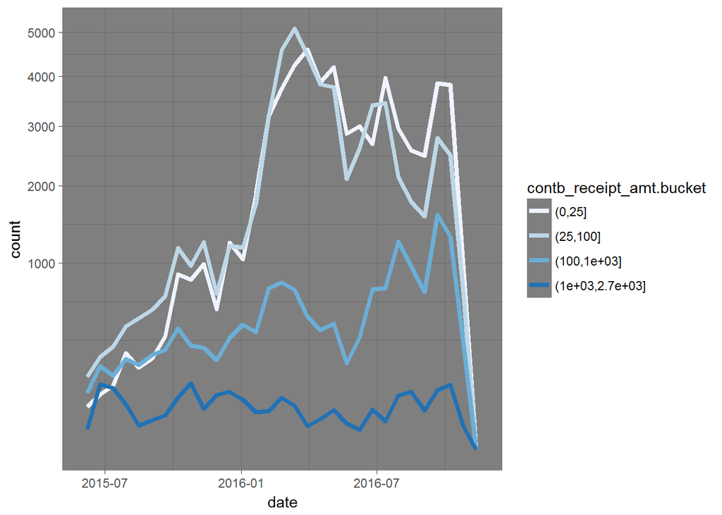

# Bivariate Analysis

### Talk about some of the relationships you observed in this part of the investigation. How did the feature(s) of interest vary with other features in the dataset?

Democrats and Republicans had more contributions, as typically expected.

### Did you observe any interesting relationships between the other features (not the main feature(s) of interest)?

The average contribution for candidate tended to be larger for candidates who were in the race for a shorter period of time. I suspect their early contributors were part of a strong base of support for the candidate and gave generous contributions.

# Multivariate Plots Section

### Donations to Democrats and Republicans

The dense scatterplot of contributions over time in the previous section was for all political parties. Here the democratic and republican contributions are separated. The contributions to democrats appears to be denser.

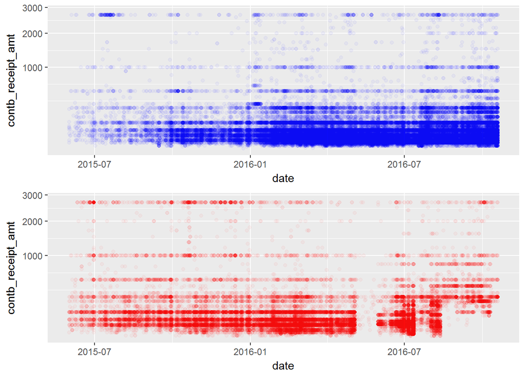

To get a better picture of how Republican and Democrat support changed over time, this chart shows the weekly number of contributions for both parties.

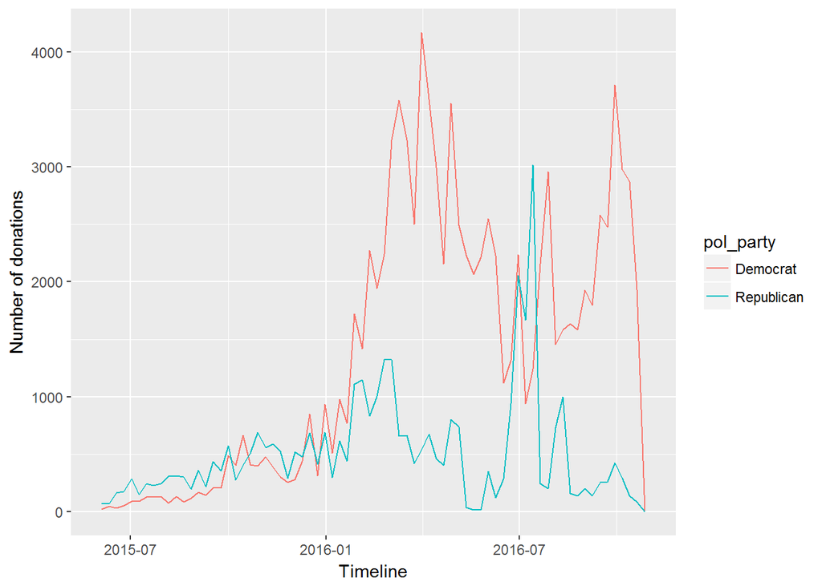

The ratio of contributions to Democrats to Republicans indicate that the monetary support for each party has not been heavily skewed to one side.

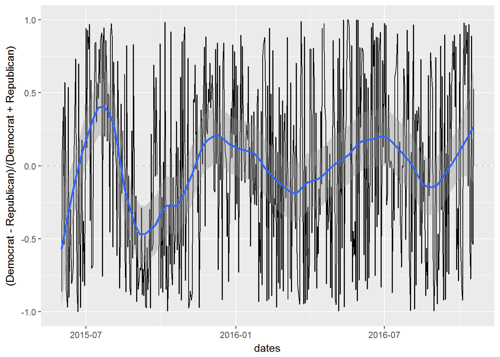

To get a better idea of the contributions to each political party per day, this chart shows a smoothed trend of the daily sum of contributions to each political party.

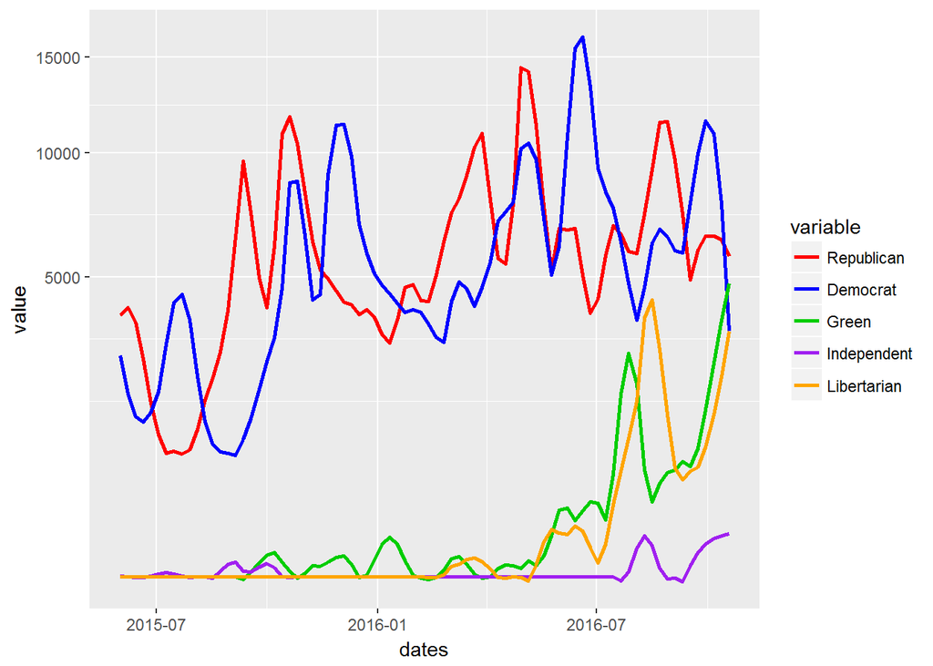

### Donations to Clinton and Trump

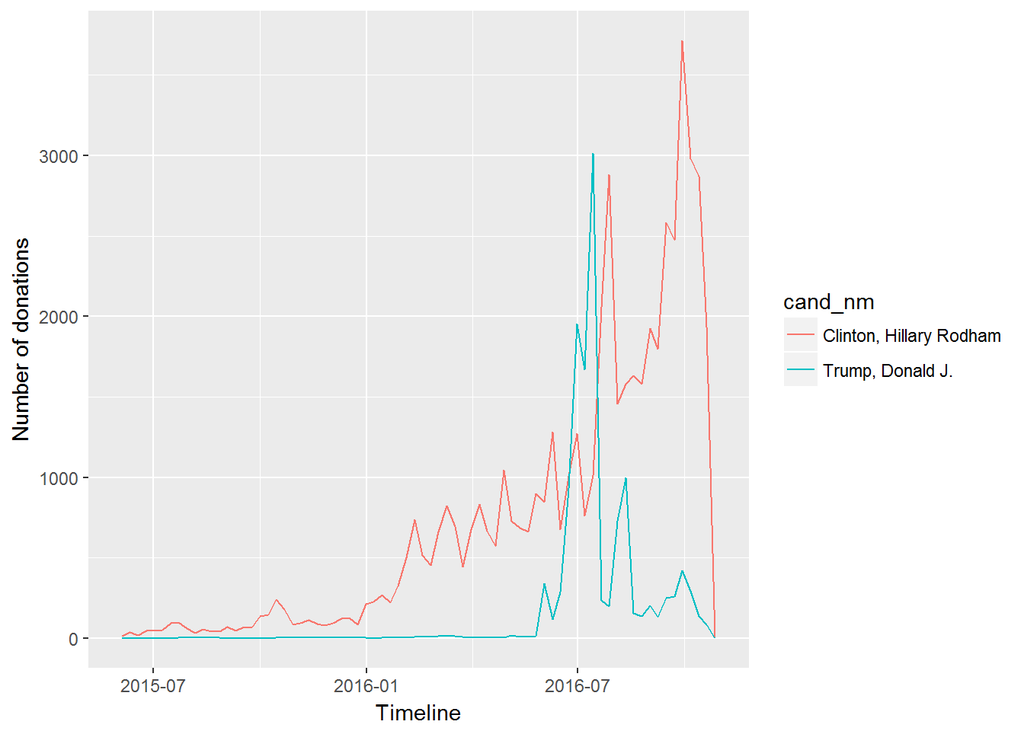

### … And Bernie

The Clinton and Trump line plot shows that before the summer of 2016, there was some support for Clinton and almost none for Trump. I suspect that Bernie would have a strong presence during that time. Here is the same chart, but including Bernie, confirming.

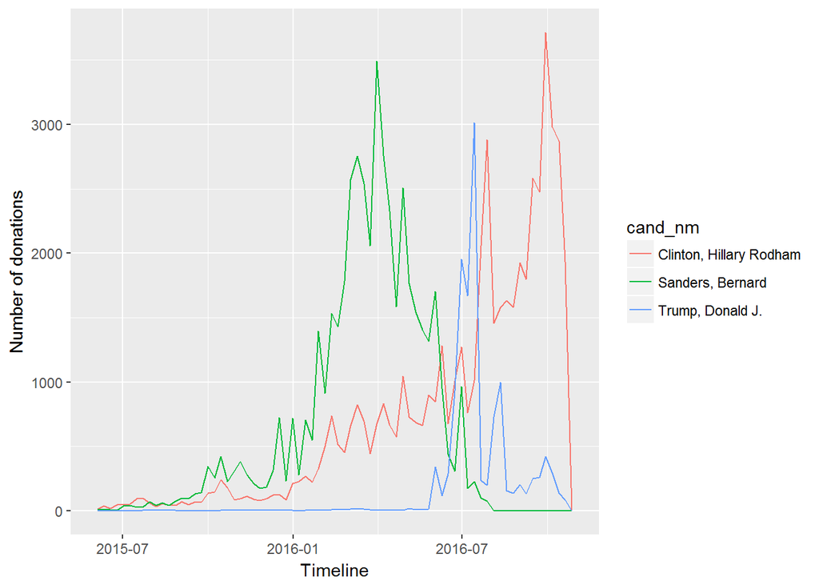

We can see in the above plot that before the summer of 2016, Bernie’s contributions from Michigan exceeded both Clinton’s and Trump’s.

The box plot below illustrates that the majority of Clinton’s contribution amounts were over a smaller range than the majority of contributions made to Trump.

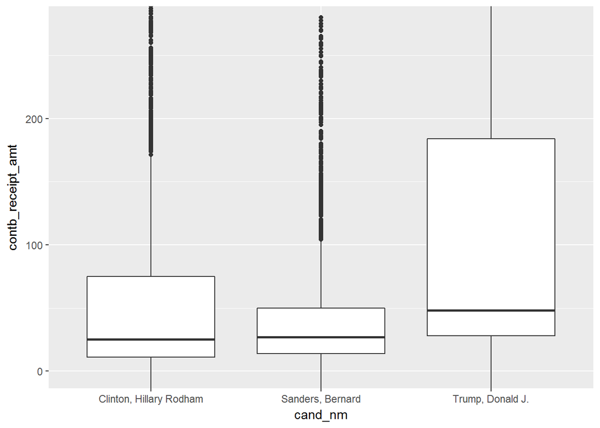

```
## hdb$cand_nm: Clinton, Hillary Rodham
##    Min. 1st Qu.  Median    Mean 3rd Qu.    Max.
## -5400.0    11.0    25.0   104.1    75.0  5400.0
## --------------------------------------------------------
## hdb$cand_nm: Sanders, Bernard
##     Min.  1st Qu.   Median     Mean  3rd Qu.     Max.
## -2700.00    14.00    27.00    41.71    50.00  2700.00
## --------------------------------------------------------
## hdb$cand_nm: Trump, Donald J.
##    Min. 1st Qu.  Median    Mean 3rd Qu.    Max.
## -2700.0    28.0    48.0   158.7   184.0  5000.0
```

### An overview of contributions for each candidate

We can take a look at the sum of contributions daily per candidate over time for an overview of each candidate’s support.

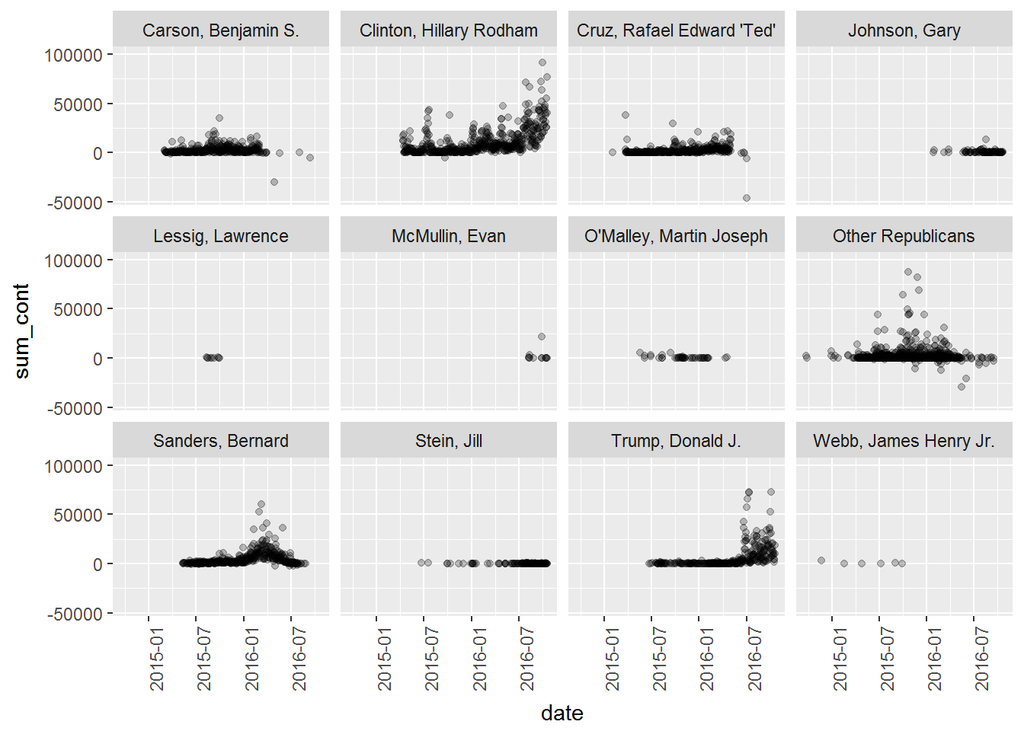

### City Trends

Political leanings are often inferred from demographics including region or location. The contributor’s city was included in the data set, and we can see what proportion of funds from each city was contributed to which party. Here is a list of the cities with the top 10 number of contributions, and colored for the proportion of funds where blue would be democratic and red republican.

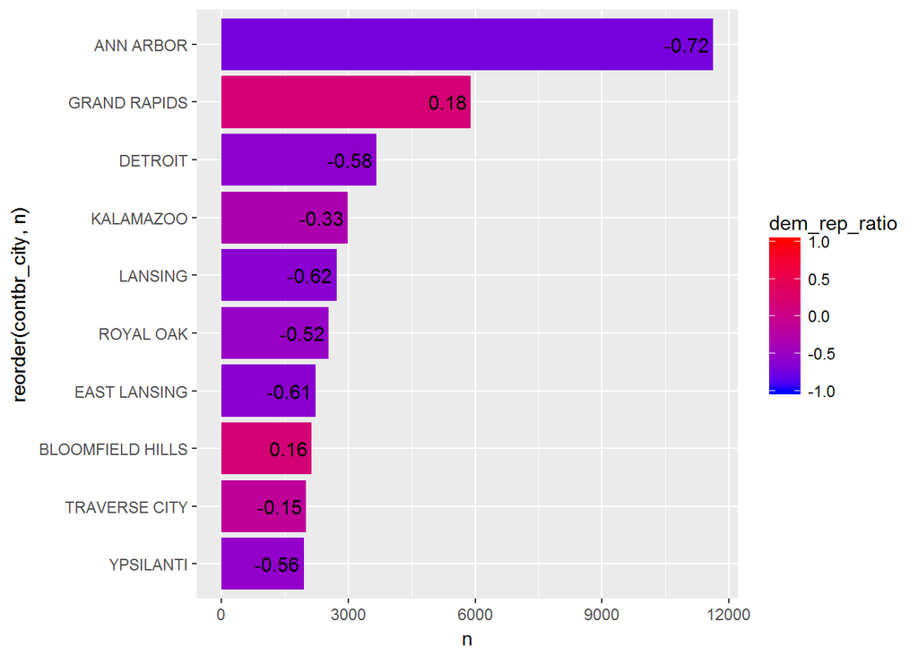

While there are too many cities to name, the trend of political leanings per city can be placed on a graph.

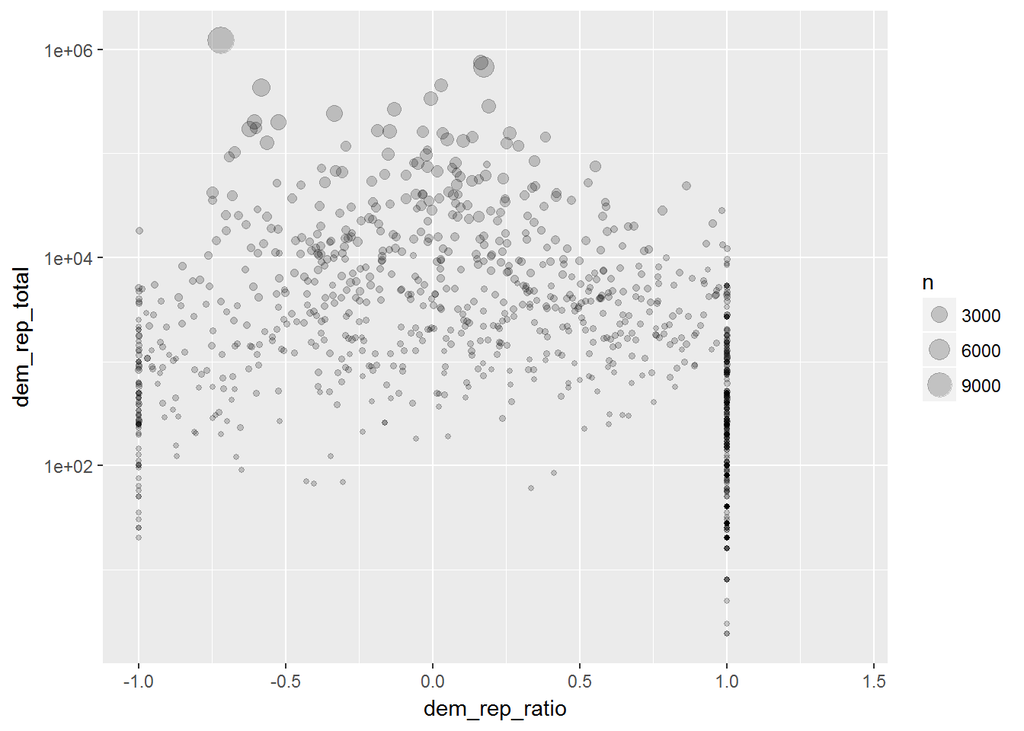

# Multivariate Analysis

### Talk about some of the relationships you observed in this part of the investigation. Were there features that strengthened each other in terms of looking at your feature(s) of interest?

This investigation compared support for political parties and specific candidates over time. In general, there were more contributions to Democrats. Contributions from each city were also explored, and the cities with the most contributions tended to be more Democrat.

### Were there any interesting or surprising interactions between features?

The donations to Trump were significantly higher in average dollar amount than to Clinton. During the dates of the national conventions, the number of contributions for these candidates rose sharply. Before that time, Bernie Sanders had a large number of contributions, but his averages were low.

# Final Plots and Summary

### Plot One

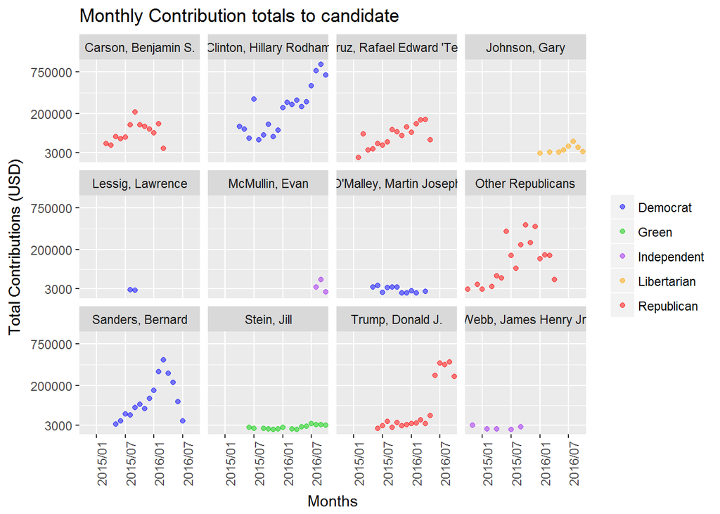

### Description One

The monthly contributions for candidate chart is used to visualize the support for each candidate over time. The data was grouped to get monthly sums which were plotted against time. Color was used to highlight the political party for each candidate. We can see that Hillary and Bernie had strong support in the race, there were more Republican candidates than Democratic candidates, and that some candidates were active only for a short time early in the campaign.

### Plot Two

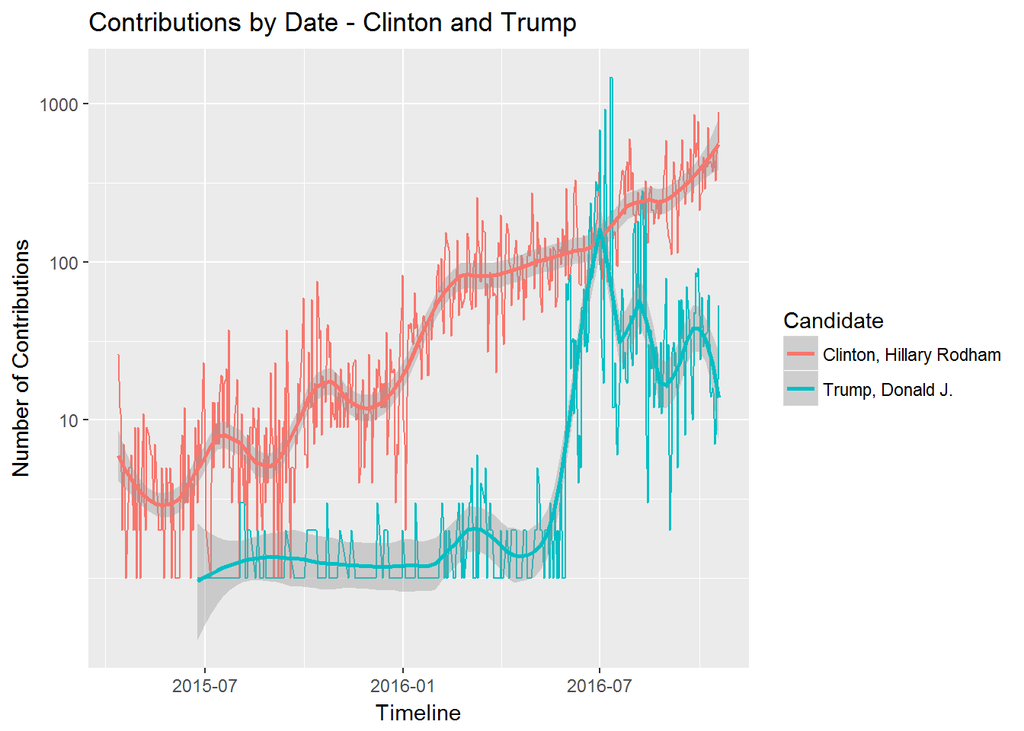

### Plot Three

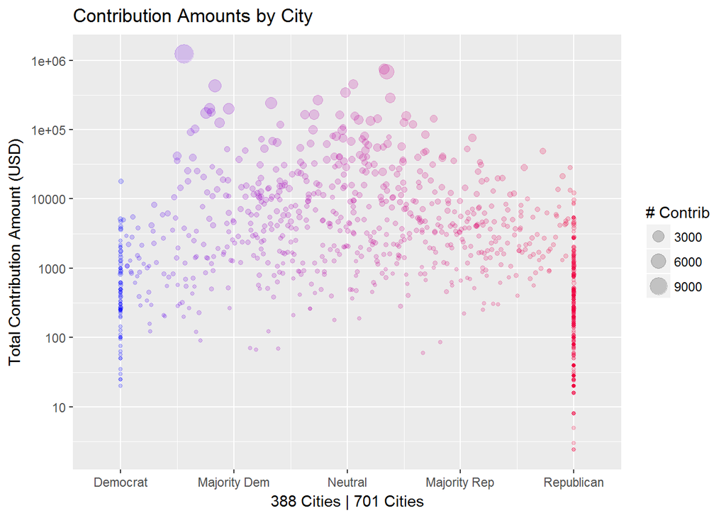

### Description Three

The above graph has a node for each city. The placement and color of the node indicate if the city was Democrat (Left, Blue) or Republican (Right, Red). The node is placed low or high based on the total contribution amount from that city. The size of the node indicates the number of contributions, and can be used go guage the size of the support base. On the far left and far right of the graph, the blue line and red line show smaller towns or are caused by inconsistent city names. The number of cities on the right side of the graph are much more than the number of cities on the left. But the cities are generally smaller so the graph doesn’t appear much denser on the right.

# Reflection

### Observations

Exploring the publicly available data of contributions to presidential campaigns has revealed that Clinton and Bernie received the highest number of contributions, while the Republican party candidates were numerous and their support scattered. As the presidential race drew on, Clinton and Trump were nominated as their party’s candidates by primary elections throughout the nation. The donations to the Trump campaign were much higher on average than the contributions to Democrats. At the time of the Republican and Democrat National Conventions, the contributions spiked sharply up.

I have not been able to decipher a large support base for Trump from this data. while the total monetary support for Trump was pretty high, the number of people supporting him specifically, as well as all Republicans, was lower. Using the number of contributions appears to be a better measure of voter support than the monetary amount of contributions, because everybody’s vote is the same whether they have $5 or $500 or not a penny to give. “The voting booth is the one place on earth where the least powerful and the most powerful are equal.” - Gloria Steinem<sup>5</sup>

### Challenges

I found that the date is a useful parameter for making meaningful graphs, but there were some very early contributions that increased the timespan too much. To overcome this, I filtered input to the graphs to be after June 1, 2015 so that the graphs would show time with a good level of activity. Another challenge was that many Republican candidates diluted the data, but simply removing candidates with less contributions would eliminate visibility to the Green, Independent and Libertarian candidates. Subsetting and sorting the list of Republican candidates helped to provide a filter. In general, there were wide ranges of values between candidates, and the smaller parties had contributions on a much smaller scale than the major parties. To maintain visibility to the wide ranges, I often used log scales.

### Additional Ideas

While I did not look at the contributor names, an important step in improving the clarity of this data would be to group the contributions by contributor to get a measure of the support base, and to clean up any refunds. It would also be interesting to see if a contributor supported more than one candidate. Cleaning up the city names and adding geographic information would be helpful in visualizing support received from different areas.

An idea that I didn’t pursue was to create monthly averages for each candidate, and compare months, because it would be interesting to see which candidates were on top in Michigan month by month of the race.